# Mental Health Disorder Analysis Final Report Draft

MGT 6203 Team 5

04/08/2022

# Data

## Data preprocessing

- Pick out factors may related to the cases of mental health disorders at the workplace.
- Extract columns in common and merge three data sets into one.
- Modify the levels of logical columns, change “0”, “1” into “No” and “Yes”.
- Modify various expression in gender column.
- Reserve the levels of the top 3 countries in CountryLiveIn and CountryWorkIn columns and combine the rest into “others”.
- Remove unreasonable age.
- Replace missing value with “unknown”.

```r
dat2019 <- read.csv("data/OSMI 2019 Mental Health in Tech Survey Results - OSMI Mental Health in Tech Survey 2019.csv", stringsAsFactors = T)
dat2020 <- read.csv("data/OSMI 2020 Mental Health in Tech Survey Results .csv", stringsAsFactors = T)
dat2021 <- read.csv("data/OSMI 2021 Mental Health in Tech Survey Results .csv", stringsAsFactors = T)

# Data For Modeling (7 Variables)
# Select columns Manually
selected_columns <- c("Do.you..currently..have.a.mental.health.disorder.",
                      "X.Are.you.self.employed..",
                      "Is.your.primary.role.within.your.company.related.to.tech.IT.",
                      "Do.you.have.a.family.history.of.mental.illness.",
                      "What.is.your.age.",
                      "What.is.your.gender.",
                      "What.country.do.you..live..in.",
                      "What.country.do.you..work..in.")
dat2019 <- dat2019 %>% select(selected_columns) %>% mutate(year = "2019")
dat2020 <- dat2020 %>% select(selected_columns) %>% mutate(year = "2020")
dat2021 <- dat2021 %>% select(selected_columns) %>% mutate(year = "2021")

dat <- rbind(dat2019, dat2020) %>%
  rbind(dat2021)
names(dat) <- c("CurrentlyMentalHealthDisorder",
                "EmploymentType",
                "JobScope",
                "FamilyHistory",
                "Age",
                "Gender",
                "CountryLiveIn",
                "CountryWorkIn",
                "year")

# Deal with gender
dat$Gender <- tolower(dat$Gender)
dat$Gender[grepl(dat$Gender, pattern = "male")] <- "male"
dat$Gender[grepl(dat$Gender, pattern = "woman")] <- "female"
dat$Gender[grepl(dat$Gender, pattern = "man")] <- "female"
dat$Gender[dat$Gender == "m"] <- "male"
dat$Gender[dat$Gender == "f"] <- "female"
dat$Gender[!(dat$Gender == "male" | dat$Gender == "female")] <- "other"
# check
# table(dat$Gender)

# Deal with CountryLiveIn
dat$CountryLiveIn <- dat$CountryLiveIn %>% as.character()
dat$CountryLiveIn[!(dat$CountryLiveIn == "United States of America" |
                      dat$CountryLiveIn == "India" |
                      dat$CountryLiveIn == "United Kingdom")] <- "other"
# Deal with CountryWorkIn
dat$CountryWorkIn <- dat$CountryWorkIn %>% as.character()
dat$CountryWorkIn[!(dat$CountryWorkIn == "United States of America" |
                      dat$CountryWorkIn == "India" |
                      dat$CountryWorkIn == "United Kingdom")] <- "other"
# Remove weird Age
dat <- dat %>%
  filter(Age < 100) %>%
  filter(Age > 18)

#Group the different age groups into 5 possible age groups
dat$AgeGroup = cut(dat$Age, c(19, 29, 39, 49, 59, Inf), c("<30", "30-39", "40-49", "50-59", ">=60"), include.lowest=TRUE)

# Merge the 4 possible outcomes into 2 outcomes
dat$CurrentlyMentalHealthDisorder <- ifelse(dat$CurrentlyMentalHealthDisorder == "Yes", "Yes", "Other")

#Percentage of Yes/Others group by Employment Type
dat <- dat %>%
  mutate(EmploymentType = ifelse(EmploymentType == 1 & !is.na(EmploymentType), "Self-Employed","Employed"))

#Rename the Job Scope into Tech, Non Tech and Unknown
dat$JobScope = if_else(dat$JobScope == 1, true= "Tech", false="Non-Tech", missing = "Unknown")

# Deal with missing value
dat$Gender[is.na(dat$Gender)] <- "Unknown"
dat$CountryLiveIn[is.na(dat$CountryLiveIn)] <- "Unknown"
dat$CountryWorkIn[is.na(dat$CountryWorkIn)] <- "Unknown"
for(i in names(dat)){
  if(is.character(dat[[i]])){
    dat[[i]] <- as.factor(dat[[i]])
  }
}
write.csv(dat, file = "eval/DataForModeling9Variables.csv", row.names = F)
dat <- dat %>% select(-year)
write.csv(dat, file = "eval/DataForModeling8Variables.csv", row.names = F)
```

## Cleaned data

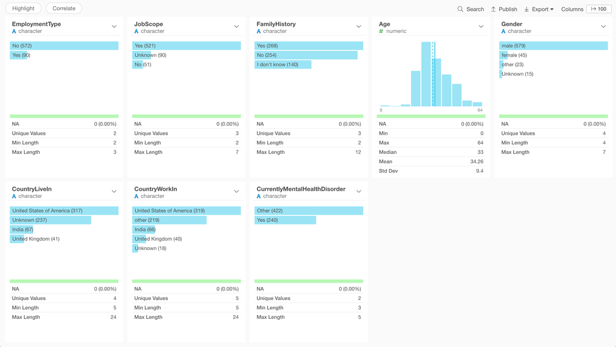

Data distribution

## Relationships between independent variable and dependent variable

The dependent variable is categorical variable, and the independent variables are both numerical and categorical variables.

1. EmploymentType vs. CurrentlyMentalHealthDisorder

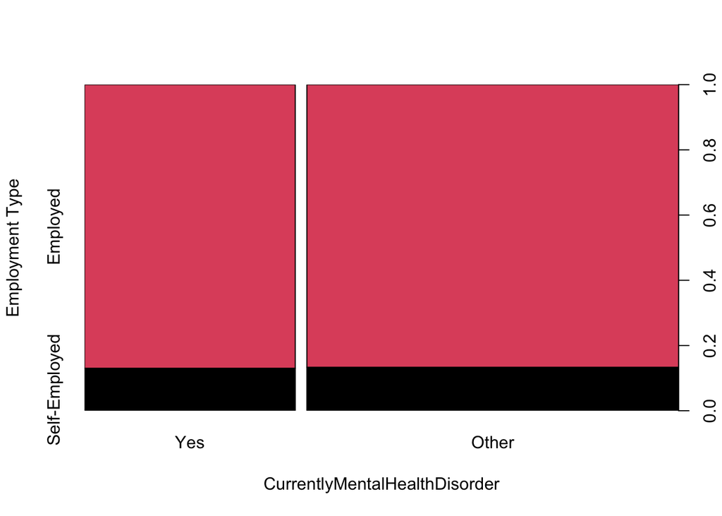

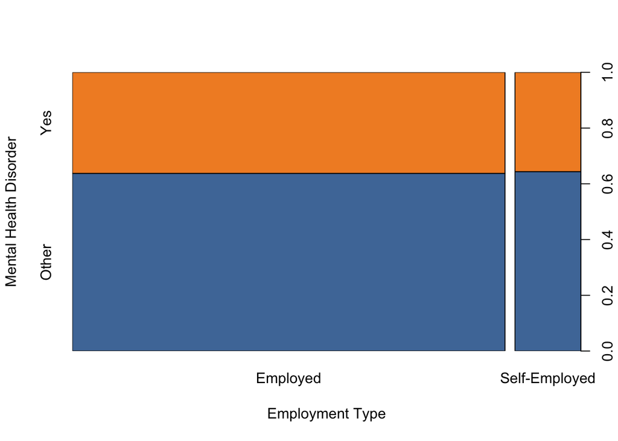

```r
spineplot(factor(dat$CurrentlyMentalHealthDisorder)~factor(dat$EmploymentType),
          xlab = "Employment Type", ylab = "Mental Health Disorder",
          col = palette("Tableau"))
```

2. JobScope vs. CurrentlyMentalHealthDisorder

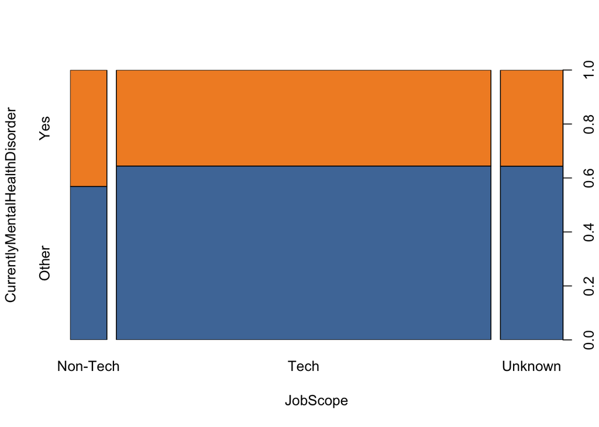

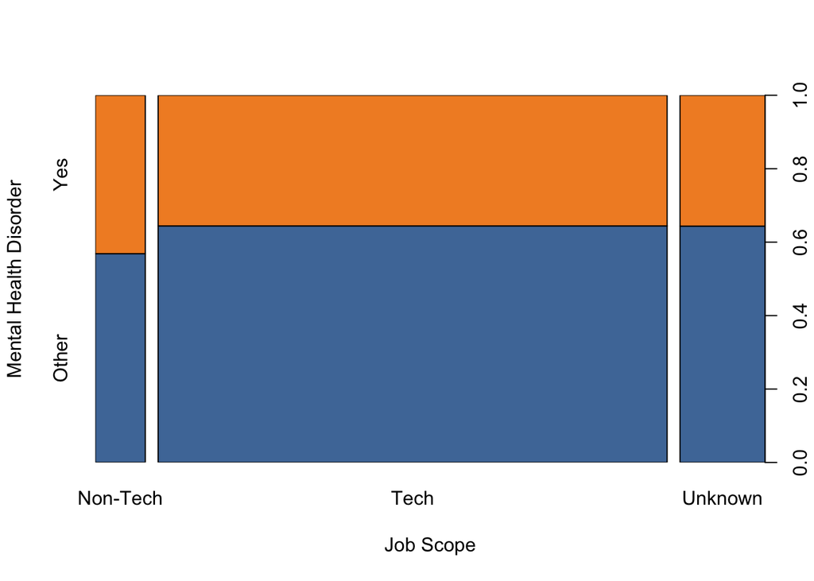

```r
spineplot(factor(dat$CurrentlyMentalHealthDisorder)~factor(dat$JobScope),
          xlab = "Job Scope", ylab = "Mental Health Disorder",
          col = palette("Tableau"))
```

3. FamilyHistory vs. CurrentlyMentalHealthDisorder

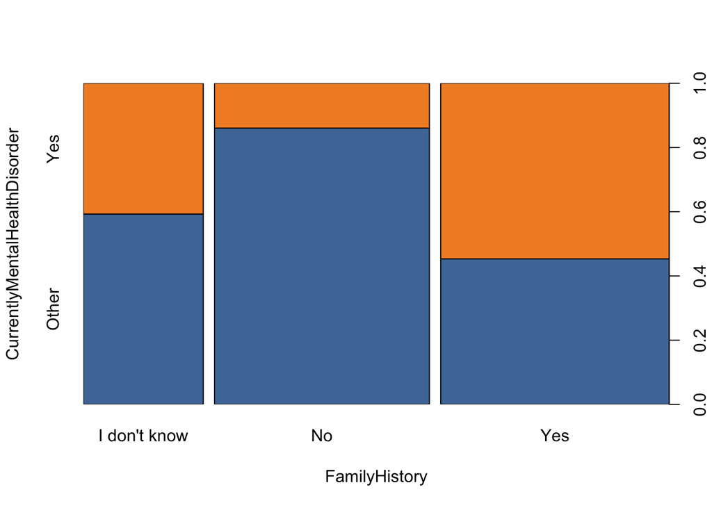

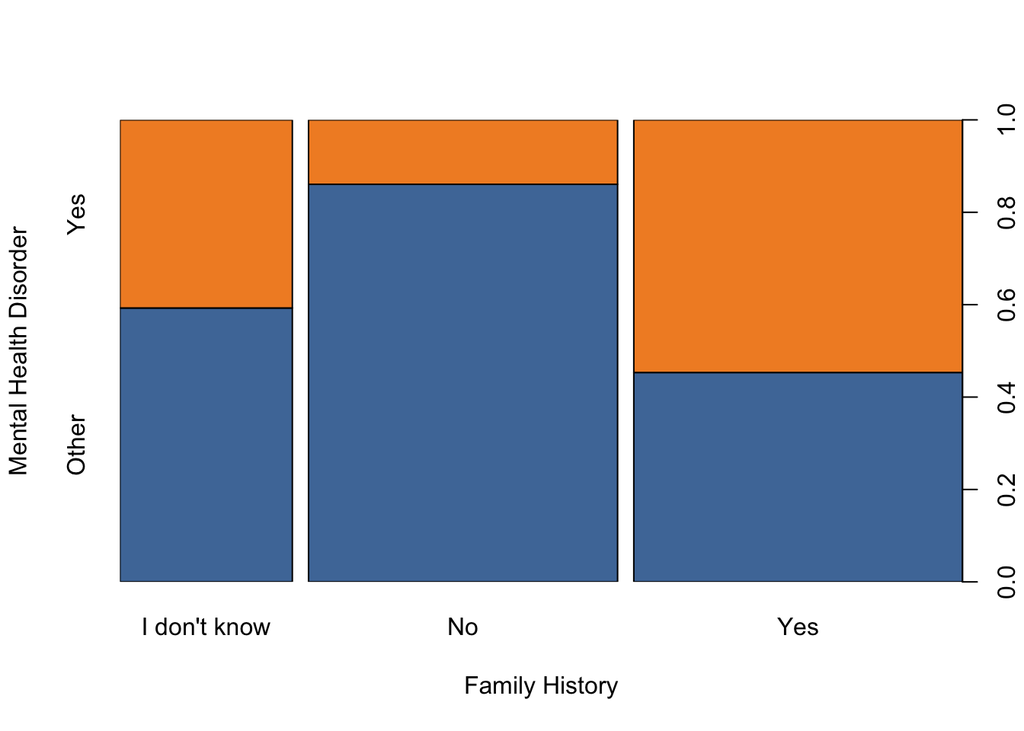

```r
spineplot(factor(dat$CurrentlyMentalHealthDisorder)~factor(dat$FamilyHistory),
          xlab = "Family History", ylab = "Mental Health Disorder",
          col = palette("Tableau"))
```

4. Gender vs. CurrentlyMentalHealthDisorder

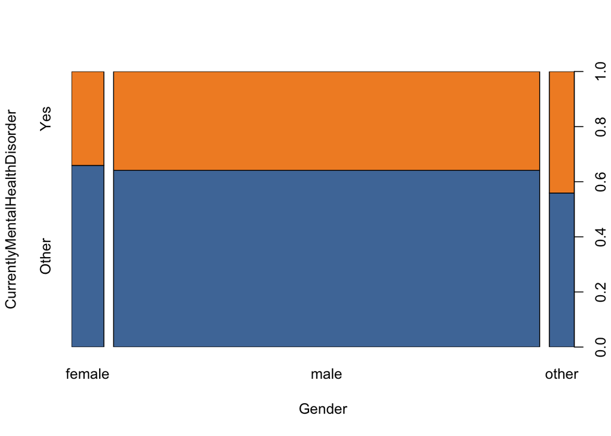

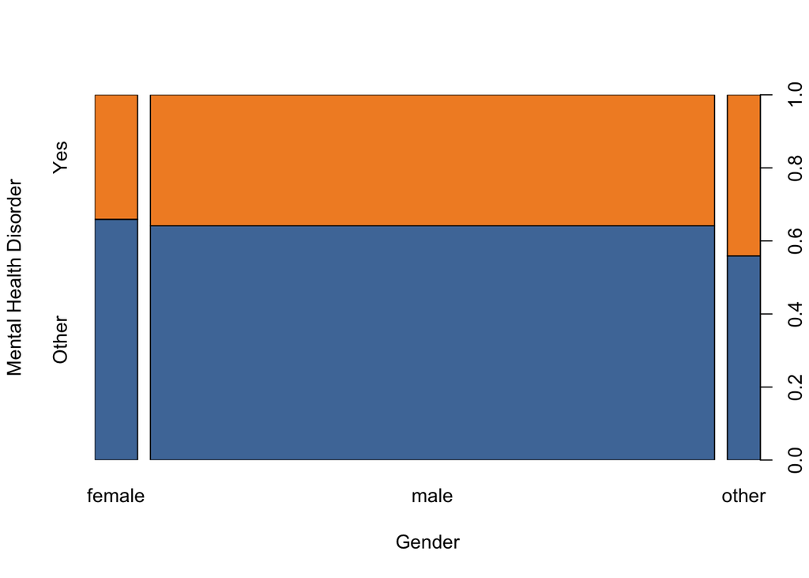

```r
spineplot(factor(dat$CurrentlyMentalHealthDisorder)~factor(dat$Gender),
          xlab = "Gender", ylab = "Mental Health Disorder",
          col = palette("Tableau"))
```

5. CountryLiveIn vs. CurrentlyMentalHealthDisorder

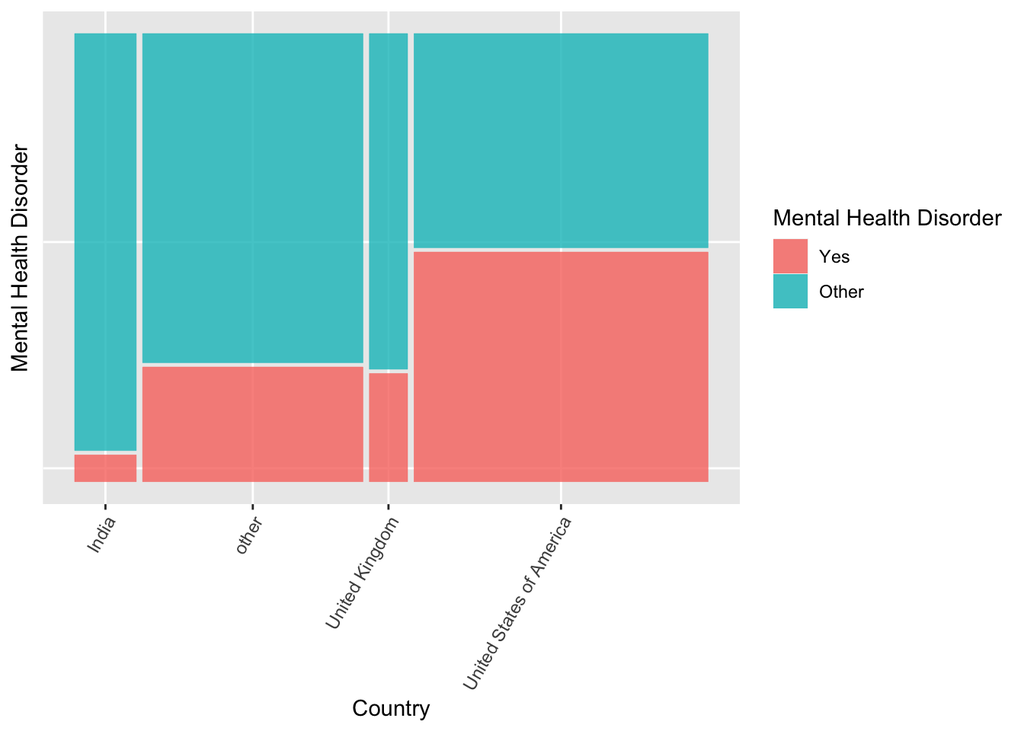

```r
ggplot(data = dat) +
  geom_mosaic(aes(x = product(CurrentlyMentalHealthDisorder, CountryLiveIn),
                  fill = CurrentlyMentalHealthDisorder)) +
  labs(y = "Mental Health Disorder",x ="Country", fill = "Mental Health Disorder") +
  theme(axis.text.y=element_blank(),
        axis.ticks.y=element_blank(),
        axis.text.x = element_text(angle = 60, hjust = 1))
```

6. CountryWorkIn vs. CurrentlyMentalHealthDisorder

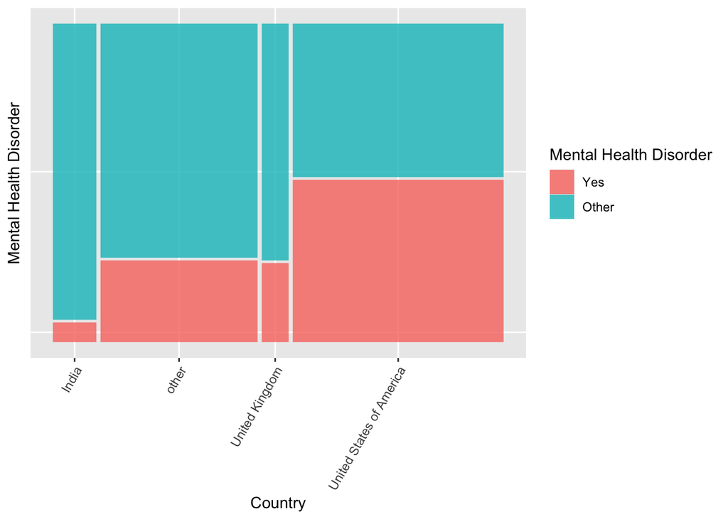

```r
ggplot(data = dat) +
  geom_mosaic(aes(x = product(CurrentlyMentalHealthDisorder, CountryWorkIn),
                  fill = CurrentlyMentalHealthDisorder)) +
  labs(y = "Mental Health Disorder",
       x = "Country",
       fill = "Mental Health Disorder") +
  theme(axis.text.y=element_blank(),
        axis.ticks.y=element_blank(),
        axis.text.x = element_text(angle = 60, hjust = 1))
```

7. AgeGroup vs. CurrentlyMentalHealthDisorder

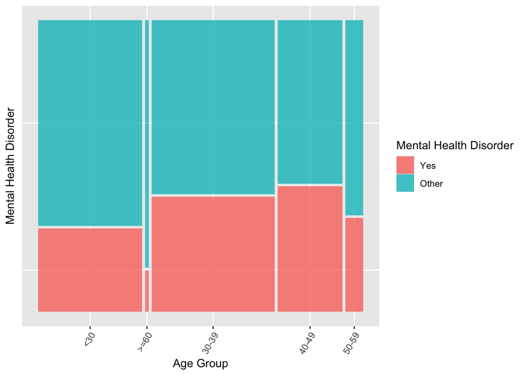

```r
ggplot(data = dat) +
  geom_mosaic(aes(x = product(CurrentlyMentalHealthDisorder, AgeGroup),
                  fill = CurrentlyMentalHealthDisorder)) +
  labs(y = "Mental Health Disorder", x= "Age Group", fill = "Mental Health Disorder") +
  theme(axis.text.y=element_blank(),
        axis.ticks.y=element_blank(),
        axis.text.x = element_text(angle = 60, hjust = 1))
```

# Approach and Methodology

## Question 1: What are the factors that might explain cases of mental health disorders at the workplace?

We build a random forest model to predict ‘Do you currently have a mental health disorder’. The confusion matrix we have is as listed below.

```r
set.seed(5)
dat <- read.csv("eval/DataForModeling8Variables.csv")
dat$CurrentlyMentalHealthDisorder <- factor(dat$CurrentlyMentalHealthDisorder, levels = c("Yes", "Other"), labels = c("Yes", "Other"))

rf1 <- randomForest(CurrentlyMentalHealthDisorder ~ EmploymentType + JobScope + FamilyHistory + Gender + CountryLiveIn + CountryWorkIn + AgeGroup,
                   data=dat,
                   na.action = na.omit)
print(rf1)
```

```
##
## Call:
##  randomForest(formula = CurrentlyMentalHealthDisorder ~ EmploymentType +      JobScope + FamilyHistory + Gender + CountryLiveIn + CountryWorkIn +      AgeGroup, data = dat, na.action = na.omit)
##                Type of random forest: classification
##                      Number of trees: 500
## No. of variables tried at each split: 2
##
##         OOB estimate of  error rate: 31.61%
## Confusion matrix:
##       Yes Other class.error
## Yes   120   118   0.4957983
## Other  90   330   0.2142857
```

We apply grid search to do the hyperparameter tuning. First, we try to find the number of features to consider at each split point(mtry) which resulted to the lowest error.

```r
# number of variables at each split
rf1.tune <- tuneRF(dat[, -which(names(dat) == "CurrentlyMentalHealthDisorder")], dat$CurrentlyMentalHealthDisorder, doBest=T)
```

```
## mtry = 2  OOB error = 33.28%
## Searching left ...
## mtry = 1     OOB error = 29.79%
## 0.1050228 0.05
## Searching right ...
## mtry = 4     OOB error = 37.54%
## -0.2602041 0.05
```

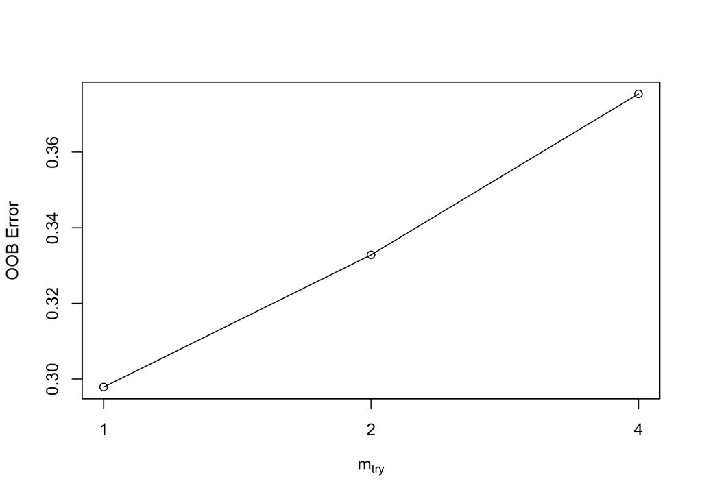

Then we search for the number of trees grown(ntree). The plot below shows the result we tried ntree=2000. We can see that the OOB Error rate converges around when ntree is around 500, the default number.

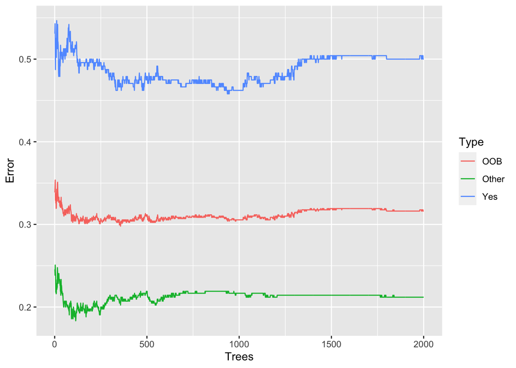

```r
rf2 <- randomForest(CurrentlyMentalHealthDisorder ~ EmploymentType + JobScope + FamilyHistory + Gender + CountryLiveIn + CountryWorkIn + AgeGroup,
                     dat, ntree = 2000)
oob_err_data <- data.frame(
  Trees = rep(1:nrow(rf2$err.rate), 3),
  Type = rep(c("OOB","Yes","Other"), each = nrow(rf2$err.rate)),
  Error = c(rf2$err.rate[,"OOB"], rf2$err.rate[,"Yes"], rf2$err.rate[,"Other"]))

ggplot(data = oob_err_data, aes(x = Trees, y= Error)) +
  geom_line(aes(color = Type))
```

```r
rf3 <-  randomForest(CurrentlyMentalHealthDisorder ~ EmploymentType + JobScope + FamilyHistory + Gender + CountryLiveIn + CountryWorkIn + AgeGroup,
                     data=dat,
                     na.action = na.omit,
                     mtry=2,
                     ntree=500)
# print(rf3)
caret::confusionMatrix(predict(rf3, newdata = dat),
                       dat$CurrentlyMentalHealthDisorder)
```

```
## Confusion Matrix and Statistics
##
##           Reference
## Prediction Yes Other
##      Yes   127    65
##      Other 111   355
##
##                Accuracy : 0.7325
##                  95% CI : (0.6969, 0.766)
##     No Information Rate : 0.6383
##     P-Value [Acc > NIR] : 1.689e-07
##
##                   Kappa : 0.3954
##
##  Mcnemar's Test P-Value : 0.0006938
##
##             Sensitivity : 0.5336
##             Specificity : 0.8452
##          Pos Pred Value : 0.6615
##          Neg Pred Value : 0.7618
##              Prevalence : 0.3617
##          Detection Rate : 0.1930
##    Detection Prevalence : 0.2918
##       Balanced Accuracy : 0.6894
##
##        'Positive' Class : Yes
##
```

The feature importance of the model is listed below.

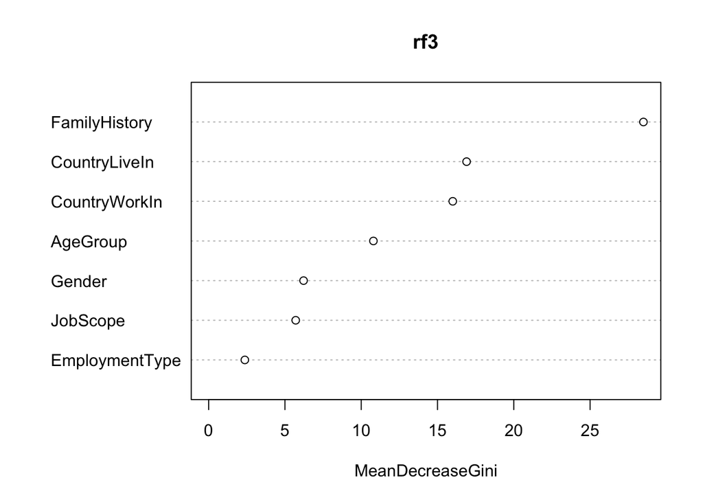

```r
varImpPlot(rf3, sort = TRUE)
```

```r
Chi_func <- function(v1, v2){
  tb <- table(v1, v2)
  chi <- chisq.test(tb, correct = F)
  chi$p.value
}

# FamilyHistory
Chi_func(dat$FamilyHistory, dat$CurrentlyMentalHealthDisorder)
```

```
## [1] 2.888205e-21
```

```r
# AgeGroup
Chi_func(dat$AgeGroup, dat$CurrentlyMentalHealthDisorder)
```

```
## [1] 0.02250287
```

```r
# CountryWorkIn
Chi_func(dat$CountryWorkIn, dat$CurrentlyMentalHealthDisorder)
```

```
## [1] 3.592461e-15
```

```r
# CountryLiveIn
Chi_func(dat$CountryLiveIn, dat$CurrentlyMentalHealthDisorder)
```

```
## [1] 1.323527e-15
```

```r
# Gender
Chi_func(dat$Gender, dat$CurrentlyMentalHealthDisorder)
```

```
## [1] 0.5955878
```

```r
#Employment Type
Chi_func(dat$EmploymentType, dat$CurrentlyMentalHealthDisorder)
```

```
## [1] 0.9107304
```

```r
#Jobscope
Chi_func(dat$JobScope, dat$CurrentlyMentalHealthDisorder)
```

```
## [1] 0.5592186
```

### Question 2: How has the pandemic changed the prevalence of mental health disorders?

```r
dat_year <- read.csv("eval/DataForModeling9Variables.csv", stringsAsFactors = T)
dat_year$Pandemic <- ifelse(dat_year$year < 2020, "Before", "After")
tb <- table(dat_year$CurrentlyMentalHealthDisorder,
            dat_year$Pandemic)
chi <- chisq.test(tb, correct = F)
chi$p.value
```

```
## [1] 0.001115939
```

We run the chi-squared test and the resulting p-value here can be seen as a measure of the correlation between these two variables. Since the p-value < 0.05, we can reject the null hypothesis. In other words, the prevalence of mental health disorders is related to the pandemic.

### Question 3: How have the attitudes towards mental health been before or after the pandemic?

There are two features are associated with this research question:

1. Would you feel comfortable discussing a mental health issue with your direct supervisor?

```r
dat2019 <- read.csv("data/OSMI 2019 Mental Health in Tech Survey Results - OSMI Mental Health in Tech Survey 2019.csv", stringsAsFactors = T) %>%
    select(DiscussWithSupervisor = `Would.you.feel.comfortable.discussing.a.mental.health.issue.with.your.direct.supervisor.s..`) %>%
    mutate(year = 2019)
dat2020 <- read.csv("data/OSMI 2020 Mental Health in Tech Survey Results .csv", stringsAsFactors = T) %>%
    select(DiscussWithSupervisor = `Would.you.feel.comfortable.discussing.a.mental.health.issue.with.your.direct.supervisor.s..`) %>%
    mutate(year = 2020)
dat2021 <- read.csv("data/OSMI 2021 Mental Health in Tech Survey Results .csv", stringsAsFactors = T) %>%
    select(DiscussWithSupervisor = `Would.you.feel.comfortable.discussing.a.mental.health.issue.with.your.direct.supervisor.s..`) %>%
    mutate(year = 2021)
dat <- rbind(dat2019, dat2020) %>%
  rbind(dat2021)

dat$Pandemic <- ifelse(dat$year < 2020, "Before", "After")
tb <- table(dat$DiscussWithSupervisor,
            dat$Pandemic)
chi <- chisq.test(tb, correct = F)
chi$p.value
```

```
## [1] 0.04401081
```

2. Would you feel comfortable discussing a mental health issue with your coworkers?

```r
dat2019 <- read.csv("data/OSMI 2019 Mental Health in Tech Survey Results - OSMI Mental Health in Tech Survey 2019.csv", stringsAsFactors = T) %>%
  select(DiscussWithCoworkers = `Would.you.feel.comfortable.discussing.a.mental.health.issue.with.your.coworkers.`) %>%
  mutate(year = 2019)
dat2020 <- read.csv("data/OSMI 2020 Mental Health in Tech Survey Results .csv", stringsAsFactors = T) %>%
  select(DiscussWithCoworkers = `Would.you.feel.comfortable.discussing.a.mental.health.issue.with.your.coworkers.`) %>%
  mutate(year = 2020)
dat2021 <- read.csv("data/OSMI 2021 Mental Health in Tech Survey Results .csv", stringsAsFactors = T) %>%
  select(DiscussWithCoworkers = `Would.you.feel.comfortable.discussing.a.mental.health.issue.with.your.coworkers.`) %>%
  mutate(year = 2021)
dat <- rbind(dat2019, dat2020) %>%
  rbind(dat2021)

dat$Pandemic <- ifelse(dat$year < 2020, "Before", "After")
tb <- table(dat$DiscussWithCoworkers,
            dat$Pandemic)
chi <- chisq.test(tb, correct = F)
chi$p.value
```

```
## [1] 0.5038958
```

We found that they have opposite results. The level of comfortableness discussing a mental health issue with the staff’s direct supervisor is different after the pandemic. On the contrary, there is no statistical difference in discussions with the staff’s coworkers.